# Lab 1: Basic Python Programming

#### CPE232 Data Models

## [1] Variable

### 1.1 Number Variable

```python
num = 100 #integer variable
num2 = 12.5 #float variable
print(num)
print(num2)

print(num + num2)   #addition
print(num - num2)   #subtraction
print(num * num2)   #multiplication
print( num / num2)  #division
```

```
100
12.5
112.5
87.5
1250.0
8.0
```

### 1.2 String Variable

```python
string = "Data Models"
print(string) #print complete string

print("Hello " + string)    #print concatenated string

# slicing string
print(string[0])            #print first character of the string
print(string[:4])           #print first to 4th character of the string
print(string[5:])           #print 6th to last character of the string
print(string[1:4])          #print 2nd to 4th character of the string
print(string * 2)           #print string 2 times
```

```
Data Models
Hello Data Models
D
Data
Models
ata
Data ModelsData Models
```

```python
# format string
code = "CPE232"

print(f"{code}: Data Models")
```

```
CPE232: Data Models
```

### 1.3 Boolean Variable

```python
#boolean variable
boolean = True
boolean2 = False

print(boolean)              #print boolean variable
print(not boolean)          #print opposite of boolean variable
print(boolean and boolean2) #print boolean and boolean2
print(boolean or boolean2)  #print boolean or boolean2
```

```
True
False
False
True
```

### 1.4 List Variable

```python
#list variable
list = ["Data",20,123.23,40,50]
another_list = ["Models",60]

print(list)                 #print complete list
print(list[0])              #print first element of the list
print(list[1:3])            #print 2nd to 3rd element of the list
print(list[2:])             #print 3rd to last element of the list
print(another_list)         #print complete another_list
print(another_list * 2)     #print another_list two times
print(list + another_list)  #print concatenated list

list[0] = "CPE232"          #change first element of the list
print(list)                 #print complete list

# add element at the end
list.append(True)
print(list)

# pop element by index
list.pop(1)
print(list)
```

```
['Data', 20, 123.23, 40, 50]
Data
[20, 123.23]
[123.23, 40, 50]
['Models', 60]
['Models', 60, 'Models', 60]
['Data', 20, 123.23, 40, 50, 'Models', 60]
['CPE232', 20, 123.23, 40, 50]
['CPE232', 20, 123.23, 40, 50, True]
['CPE232', 123.23, 40, 50, True]
```

### 1.5 Tuple Variable

```python
#tuple variable
tuple = ("Data",20,123.23,40,50)
another_tuple = ("Models",60)

print(tuple)                    #print complete tuple
print(tuple[0])                 #print first element of the tuple
print(tuple[1:3])               #print 2nd to 3rd element of the tuple
print(tuple[2:])                #print 3rd to last element of the tuple
print(tuple * 2)                #print tuple two times
print(tuple + another_tuple)    #print concatenated tuple
```

```
('Data', 20, 123.23, 40, 50)
Data
(20, 123.23)
(123.23, 40, 50)
('Data', 20, 123.23, 40, 50, 'Data', 20, 123.23, 40, 50)
('Data', 20, 123.23, 40, 50, 'Models', 60)
```

```python
tuple[0] = "CPE232"          # tuple is immutable dtype, we can't change its value after declared
```

```
---------------------------------------------------------------------------
TypeError                                 Traceback (most recent call last)
Cell In[9], line 1
----> 1 tuple[0] = "CPE232"          # tuple is immutable dtype, we can't change its value after declared

TypeError: 'tuple' object does not support item assignment
```

### 1.6 Dictionary Variable

```python
#dictionary variable
dictionary = {"name":"Alice","age":21}
another_dictionary = {}
another_dictionary["name"] = "Bob"
another_dictionary["age"] = 21

print(dictionary)                  #print complete dictionary
print(dictionary["name"])          #print value for specific key
print(dictionary.keys())           #print all the keys
print(dictionary.values())         #print all the values
print(dictionary.items())          #print all the items
print(another_dictionary)          #print complete another_dictionary
```

```
{'name': 'Alice', 'age': 21}
Alice
dict_keys(['name', 'age'])
dict_values(['Alice', 21])
dict_items([('name', 'Alice'), ('age', 21)])
{'name': 'Bob', 'age': 21}
```

### 1.7 Set Variable

```python
#set variable
my_set = {"Data",20,123.23,60,"Data"}
another_set = {"Models", 60}

print(my_set)                               #print complete set (duplicates are removed)

#set operations
print(my_set.union(another_set))            # print all unique elements from both sets
print(my_set.intersection(another_set))     # print common elements from both sets

# add element
my_set.add("New Item")
my_set.add(20)                              # try adding a duplicate again
print(my_set)

# remove element
my_set.remove(123.23)
print(my_set)
```

```
{'Data', 123.23, 20, 60}
{'Data', 20, 'Models', 123.23, 60}
{60}
{'Data', 'New Item', 20, 123.23, 60}
{'Data', 'New Item', 20, 60}
```

## [2] Control Flow

### 2.1 IF ... ELIF ... ELSE

```python
number = 123
number2 = 34

if number > number2:
    print("number is greater than number2")
elif number < number2:
    print("number is less than number2")
else:
    print("number is equal to number2")
```

```
number is greater than number2
```

### 2.2 try ... except

```python
number1 = "number"
number2 = 2

try:
    number1 + number2
except:                             #error handling
    print("What are you doing?")
```

```
What are you doing?
```

## [3] Loop

### 3.1 For Loop

```python
#for loops
for num in range(0,10):
    print(num)
```

```
0
1
2
3
4
5
6
7
8
9
```

```python
#for loops with step
for num in range(5,15,2):
    print(num)
```

```
5
7
9
11
13
```

```python
#for loop with enumerate

list = ["Alice","Bob","Charlie","Daisy"]

for index, name in enumerate(list):
    print(f"{index}: {name}")
```

```
0: Alice
1: Bob
2: Charlie
3: Daisy
```

```python
#for loop with list

for name in list:
    print(name)
```

```
Alice
Bob
Charlie
Daisy
```

```python
#continue in for loop

list = [1,23,7,"hello",True,1123,43,23,12]

for element in list:
    if type(element) != int:
        continue
    print(element)
```

```
1
23
7
1123
43
23
12
```

```python
#break in for loop

list = [1,23,7,"hello",True,1123,43,23,12]

for element in list:
    if type(element) != int:
        break
    print(element)
```

```
1
23
7
```

### 3.2 While loop

```python
#while loop

list = ["Alice","Bob","Charlie","Daisy"]
count = 0

while count < len(list):
    print(list[count])
    count += 1
```

```
Alice
Bob
Charlie
Daisy
```

```python
#continue in while loop

list = [1,23,7,"hello",True,1123,43,23,12]
count = 0

while count < len(list):
    if type(list[count]) != int:
        count += 1
        continue
    print(list[count])
    count += 1
```

```
1
23
7
1123
43
23
12
```

```python
#break in while loop

list = [1,23,7,"hello",True,1123,43,23,12]
count = 0

while count < len(list):
    if type(list[count]) != int:
        break
    print(list[count])
    count += 1
```

```
1
23
7
```

## [4] Function

```python
#define function
def function_name (arg1, arg2):
    return arg1 + arg2

#calling function
function_name(1,2)
```

```
3
```

```python
#define function with default argument
def function_with_default_arg(arg1, arg2 = 10, arg3 = 20 , arg4 = 30):
    return arg1 + arg2 + arg3 + arg4

result_1 = function_with_default_arg(1)
result_2 = function_with_default_arg(1,2,5)
result_3 = function_with_default_arg(1,2,5,10)

print(result_1)
print(result_2)
print(result_3)
```

```
61
38
18
```

```python
#multiple arguments
def function_with_multiple_arg(*args):
    print(args)
    print(type(args))
    sum = 0
    for num in args:
        sum += num

    return sum

function_with_multiple_arg(1,2,3,4,5)
```

```
(1, 2, 3, 4, 5)
<class 'tuple'>
```

```
15
```

```python
#lambda function
lambda_function = lambda arg1, arg2: arg1 + arg2

print(lambda_function(1,2))
```

```
3
```

## [5] OOP

```python
class Car:
    """A simple attempt to represent a car."""

    def __init__(self, make, model, year):
        """Initialize attributes to describe a car."""
        self.make = make
        self.model = model
        self.year = year
        self.odometer_reading = 0

    def get_description_name(self):
        """Return a neatly formatted descriptive name."""
        long_name = f"{self.year} {self.make} {self.model}"
        return long_name.title()

    def read_odometer(self):
        """Print a statement showing the car's mileage."""
        print(f"This car has {self.odometer_reading} miles on it.")

    def update_odometer(self, mileage):
        """Set the odometer reading to the given value."""
        self.odometer_reading = mileage
```

```python
my_car = Car("Honda", "Civic", 2016)
my_car.read_odometer()

# update odometer
my_car.update_odometer(50)
my_car.read_odometer()
```

```
This car has 0 miles on it.
This car has 50 miles on it.
```

## [6] File Handling

### 6.1 Text File

```python
# write file
with open("test.txt","w") as file:
    file.write("Hello World")

# read file
with open("test.txt","r") as file:
    print(file.read())
```

```
Hello World
```

### 6.2 CSV File

```python
import csv

with open("test.csv", "w", newline='') as file:
        writer = csv.writer(file)
        writer.writerow(["Name","Surname"])
        writer.writerow(["Alice","Johnson"])
        writer.writerow(["Bob","Smith"])
```

```python
import csv

with open("test.csv","r") as file:
    reader = csv.reader(file)
    for row in reader:
        print(row)
```

```
['Name', 'Surname']
['Alice', 'Johnson']
['Bob', 'Smith']
```

### 6.3 JSON file

```python
import json

data = {
    "username": "admin",
    "password": "admin",
    "role": "sleeping",
}

with open('test.json', 'w') as f:
    json.dump(data, f)
```

```python
with open("test.json", "r") as f:
    data = json.load(f)

data
```

```
{'username': 'admin', 'password': 'admin', 'role': 'sleeping'}
```

## [7] Libraries

### 7.1 Numpy

#### import numpy library

```python
%pip install numpy
import numpy as np
```

#### ndarray initialization

Construct using python list

```python
# 1d ndarray from 1d python list
list_a1=[1,2,3.5]
arr_a1=np.array(list_a1)
arr_a1
```

```
array([1. , 2. , 3.5])
```

```python
# 2d ndarray from 2d python list (list of list)
list_a2=[[1,2],[3,4],[5,6]]
arr_a2=np.array(list_a2)
arr_a2
```

```
array([[1, 2],
       [3, 4],
       [5, 6]])
```

```python
list_a3=[ [[1,2],[2,3]], [[3,4],[4,5]] ]
arr_a3=np.array(list_a3)
arr_a3
```

```
array([[[1, 2],
        [2, 3]],

       [[3, 4],
        [4, 5]]])
```

or construct using some numpy classes and functions

```python
np.zeros(5)
```

```
array([0., 0., 0., 0., 0.])
```

```python
np.ones((3,4),dtype=float)
```

```
array([[1., 1., 1., 1.],
       [1., 1., 1., 1.],
       [1., 1., 1., 1.]])
```

```python
np.eye(3, 3)
```

```
array([[1., 0., 0.],
       [0., 1., 0.],
       [0., 0., 1.]])
```

```python
np.full((4,),999)
```

```
array([999, 999, 999, 999])
```

```python
np.arange(3,10,2)
```

```
array([3, 5, 7, 9])
```

```python
np.linspace(0, 1, 5)
```

```
array([0.  , 0.25, 0.5 , 0.75, 1.  ])
```

```python
np.random.choice(['a','b'], 9)
```

```
array(['a', 'b', 'a', 'b', 'b', 'a', 'b', 'b', 'a'], dtype='<U1')
```

```python
np.random.randn(10)
```

```
array([ 1.05722529, -1.30395375,  0.64071357,  0.89152784, -1.9461776 ,
       -1.12472831,  1.78123632,  0.40012828,  0.65449476,  0.30295749])
```

#### ndarray properties

```python
list_a=[[1,2,3,4],[5,6,7,8],[9,10,11,12]]
arr_a=np.array(list_a)
arr_a
```

```
array([[ 1,  2,  3,  4],
       [ 5,  6,  7,  8],
       [ 9, 10, 11, 12]])
```

```python
print("dimension:", arr_a.ndim)
print("shape:", arr_a.shape)
print("data type:", arr_a.dtype)
print("array's size (elements)", arr_a.size)
```

```
dimension: 2
shape: (3, 4)
data type: int64
array's size (elements) 12
```

#### Reshaping & Modification

from this original ndarray

```python
arr_a
```

```
array([[ 1,  2,  3,  4],
       [ 5,  6,  7,  8],
       [ 9, 10, 11, 12]])
```

try to convert into 3D array

```python
arr_a.reshape((2,2,3))
```

```
array([[[ 1,  2,  3],
        [ 4,  5,  6]],

       [[ 7,  8,  9],
        [10, 11, 12]]])
```

sometimes you may resize for same dimension where only known some dimension, insert -1 for unknown len

```python
arr_a.reshape((-1,6))
```

```
array([[ 1,  2,  3,  4,  5,  6],
       [ 7,  8,  9, 10, 11, 12]])
```

Would you like to try this?

```python
arr_a.reshape((-1,5))
```

```
---------------------------------------------------------------------------
ValueError                                Traceback (most recent call last)
Cell In[179], line 1
----> 1 arr_a.reshape((-1,5))

ValueError: cannot reshape array of size 12 into shape (5)
```

[Q1] From the above cell, explain in your own words why it worked or did not work.

Ans: ไม่สามารถรันได้ เนื่องจาก arr_a ไม่สามารถแบ่งเป็น 5 columns ได้ โดยที่ให้แต่ละ rows มีสมาชิกเท่ากัน ถ้าจะให้รันได้ต้องแบ่งจำนวน columns เป็นเลขที่หาร 12 ลงตัว

Next, try to append any value(s) into existing 2darray

```python
np.append(arr_a, 13)
```

```
array([ 1,  2,  3,  4,  5,  6,  7,  8,  9, 10, 11, 12, 13])
```

```python
np.append(arr_a, arr_a[0])
```

```
array([ 1,  2,  3,  4,  5,  6,  7,  8,  9, 10, 11, 12,  1,  2,  3,  4])
```

```python
np.append(arr_a,arr_a[0].reshape((1,-1)),axis=0)
```

```
array([[ 1,  2,  3,  4],
       [ 5,  6,  7,  8],
       [ 9, 10, 11, 12],
       [ 1,  2,  3,  4]])
```

```python
np.append(arr_a,arr_a[:,0].reshape((-1,1)),axis=1)
```

```
array([[ 1,  2,  3,  4,  1],
       [ 5,  6,  7,  8,  5],
       [ 9, 10, 11, 12,  9]])
```

```python
np.concatenate([arr_a,arr_a])
```

```
array([[ 1,  2,  3,  4],
       [ 5,  6,  7,  8],
       [ 9, 10, 11, 12],
       [ 1,  2,  3,  4],
       [ 5,  6,  7,  8],
       [ 9, 10, 11, 12]])
```

```python
np.concatenate([arr_a,arr_a],axis=1)
```

```
array([[ 1,  2,  3,  4,  1,  2,  3,  4],
       [ 5,  6,  7,  8,  5,  6,  7,  8],
       [ 9, 10, 11, 12,  9, 10, 11, 12]])
```

#### indexing & slicing

from this original array again

```python
arr_a
```

```
array([[ 1,  2,  3,  4],
       [ 5,  6,  7,  8],
       [ 9, 10, 11, 12]])
```

```python
arr_a[1]
```

```
array([5, 6, 7, 8])
```

```python
arr_a[1][2]
arr_a[1,2]
```

```
np.int64(7)
```

```python
arr_a[1,1:]
```

```
array([6, 7, 8])
```

```python
arr_a[:2, 1:]
```

```
array([[2, 3, 4],
       [6, 7, 8]])
```

sometimes you may specify some row number using list within indexing

```python
arr_a[[1,2,1], 1:]
```

```
array([[ 6,  7,  8],
       [10, 11, 12],
       [ 6,  7,  8]])
```

#### Boolean slicing

based on this original array

```python
arr_a
```

```
array([[ 1,  2,  3,  4],
       [ 5,  6,  7,  8],
       [ 9, 10, 11, 12]])
```

try to filter all elements which more than 5

```python
arr_a>5
```

```
array([[False, False, False, False],
       [False,  True,  True,  True],
       [ True,  True,  True,  True]])
```

Next, try to filter all elements which more than 5 and less than 10

```python
(arr_a>5)&(arr_a<10)
```

```
array([[False, False, False, False],
       [False,  True,  True,  True],
       [ True, False, False, False]])
```

Run the cell below and answer a question.

```python
arr_a[(arr_a>5)&(arr_a<10)]
```

```
array([6, 7, 8, 9])
```

[Q2] From the above cell, explain in your own words how the output came about?

Ans: Output ที่ออกมาคือ ตัวเลขที่ Intersection กันระหว่างเซตที่มากกว่า 5 และ น้อยกว่า 10 หรือจะมองอีกแบบคือ เป็นการเทียบตัวเลขที่ละตัวว่ามากกว่า 5 และ น้อยกว่า 10 หรือไม่ ถ้าเป็นจริงจะพิมพ์ออกมา

Try running the cell below.

```python
arr_a[(arr_a>5) and (arr_a<10)]
```

```
---------------------------------------------------------------------------
ValueError                                Traceback (most recent call last)
Cell In[196], line 1
----> 1 arr_a[(arr_a>5) and (arr_a<10)]

ValueError: The truth value of an array with more than one element is ambiguous. Use a.any() or a.all()
```

[Q3] Explain in your own words why the above cell gives an error.

Ans: ที่ error เพราะ and เป็นการเทียบทั้ง Array เลย แต่ใน Array มีหลาย element จึงไม่สามารถนำมาเทียบได้ แต่ถ้าใช้ & เป็น operator จะเป็นการนำมาเทียบที่ละตัว

[Q4] And what should be written instead so that the code is error-free?

Ans: เปลี่ยนจาก and เป็น & คือ arr_a[(arr_a > 5) & (arr_a < 10)]

#### Basic operations

```python
list_b=[[1,2,3,4],[1,2,3,4],[1,2,3,4]]
arr_b=np.array(list_b)
arr_b
```

```
array([[1, 2, 3, 4],
       [1, 2, 3, 4],
       [1, 2, 3, 4]])
```

This is some operations for only 1 array

```python
np.sqrt(arr_b)
```

```
array([[1.        , 1.41421356, 1.73205081, 2.        ],
       [1.        , 1.41421356, 1.73205081, 2.        ],
       [1.        , 1.41421356, 1.73205081, 2.        ]])
```

This is some operations for 2 arrays with the same shape

```python
arr_a-arr_b
```

```
array([[0, 0, 0, 0],
       [4, 4, 4, 4],
       [8, 8, 8, 8]])
```

```python
np.add(arr_a,arr_b)
```

```
array([[ 2,  4,  6,  8],
       [ 6,  8, 10, 12],
       [10, 12, 14, 16]])
```

Next, try to operate with 1 array and one numeric variable

```python
arr_a*3
```

```
array([[ 3,  6,  9, 12],
       [15, 18, 21, 24],
       [27, 30, 33, 36]])
```

```python
1+arr_a**2
```

```
array([[  2,   5,  10,  17],
       [ 26,  37,  50,  65],
       [ 82, 101, 122, 145]])
```

#### Broadcasting

```python
arr_c=np.array([1,2,3])
arr_d=np.array([[3],[5],[8]])
```

```python
arr_c-arr_d
```

```
array([[-2, -1,  0],
       [-4, -3, -2],
       [-7, -6, -5]])
```

#### Basic aggregations

```python
arr_a

print(arr_a)
print("sum:", arr_a.sum())
print("mean:", arr_a.mean())
print("min:", arr_a.min())
print("max:", arr_a.max())
print("standard deviation:", arr_a.std())
```

```
[[ 1  2  3  4]
 [ 5  6  7  8]
 [ 9 10 11 12]]
sum: 78
mean: 6.5
min: 1
max: 12
standard deviation: 3.452052529534663
```

#### ndarray axis

```python
# column axis
arr_a.sum(axis=0)
```

```
array([15, 18, 21, 24])
```

```python
# row axis
arr_a.sum(axis=1)
```

```
array([10, 26, 42])
```

[Q5] Summarize the value of the argument *axis*, what is the value for row-wise summation and column-wise summation, respectively?

Ans: Array ตัวอย่าง คือ [ 1 2 3 4] [ 5 6 7 8] [ 9 10 11 12] axis = 1 คือ แถวเป็นการบวกเลขของทั้งแถว เช่น แถวที่ 1 ผลบวกคือ 1 + 2 + 3 + 4 = 10 ซึ่งคือ ผลรวมของแถวแรก axis = 0 คือ หลักเป็นการบวกเลขทั้งหลัก เช่น หลักที่ 1 ผลบวกคือ 1 + 5 + 9 = 15 ซึ่งคือ ผลรวมของหลักแรก

### 7.2 Pandas

#### Series

```python
%pip install pandas
import pandas as pd
import numpy as np
```

```python
pd.Series(np.random.randn(6))
```

```
0    0.831758
1   -0.576298
2    0.767423
3    0.555864
4   -0.062981
5    1.421770
dtype: float64
```

```python
pd.Series(np.random.randn(6), index=['a','b','c','d','e','f'])
```

```
a    0.354842
b   -0.129313
c   -1.497792
d    1.191249
e   -0.643312
f    0.089230
dtype: float64
```

#### Constructing Dataframe

Constructing DataFrame from a dictionary

```python
d = {'col1':[1,2], 'col2': [3,4]}
```

```python
df = pd.DataFrame(data=d)
df
```

|  | col1 | col2 |
| --- | --- | --- |
| 0 | 1 | 3 |
| 1 | 2 | 4 |

```python
d2 = {'Name':['Joe','Nat','Harry','Sam','Monica'],
      'Age': [20,21,19,20,22]}

df2 = pd.DataFrame(data=d2)
df2
```

|  | Name | Age |
| --- | --- | --- |
| 0 | Joe | 20 |
| 1 | Nat | 21 |
| 2 | Harry | 19 |
| 3 | Sam | 20 |
| 4 | Monica | 22 |

Constructing DataFrame from a List

```python
marks_list = [85.10, 77.80, 91.54, 88.78, 60.55]

df3 = pd.DataFrame(marks_list, columns=['Marks'])
df3
```

|  | Marks |
| --- | --- |
| 0 | 85.10 |
| 1 | 77.80 |
| 2 | 91.54 |
| 3 | 88.78 |
| 4 | 60.55 |

Creating DataFrame from file

```python
# Read csv file from path and store to df for create dataframe
df = pd.read_csv('nss15.csv')
df
```

|  | caseNumber | treatmentDate | statWeight | stratum | age | sex | race | diagnosis | bodyPart | disposition | location | product |
| --- | --- | --- | --- | --- | --- | --- | --- | --- | --- | --- | --- | --- |
| 0 | 150733174 | 7/11/2015 | 15.7762 | V | 5 | Male | NaN | 57 | 33 | 1 | 9 | 1267 |
| 1 | 150734723 | 7/6/2015 | 83.2157 | S | 36 | Male | White | 57 | 34 | 1 | 1 | 1439 |
| 2 | 150817487 | 8/2/2015 | 74.8813 | L | 20 | Female | NaN | 71 | 94 | 1 | 0 | 3274 |
| 3 | 150717776 | 6/26/2015 | 15.7762 | V | 61 | Male | NaN | 71 | 35 | 1 | 0 | 611 |
| 4 | 150721694 | 7/4/2015 | 74.8813 | L | 88 | Female | Other | 62 | 75 | 1 | 0 | 1893 |
| ... | ... | ... | ... | ... | ... | ... | ... | ... | ... | ... | ... | ... |
| 334834 | 150739278 | 5/31/2015 | 15.0591 | V | 7 | Male | NaN | 59 | 76 | 1 | 1 | 1864 |
| 334835 | 150733393 | 7/11/2015 | 5.6748 | C | 3 | Female | Black | 68 | 85 | 1 | 0 | 1931 |
| 334836 | 150819286 | 7/24/2015 | 15.7762 | V | 38 | Male | NaN | 71 | 79 | 1 | 0 | 3250 |
| 334837 | 150823002 | 8/8/2015 | 97.9239 | M | 38 | Female | White | 59 | 82 | 1 | 1 | 464 |
| 334838 | 150723074 | 6/20/2015 | 49.2646 | M | 5 | Female | White | 57 | 34 | 1 | 9 | 3273 |

334839 rows × 12 columns

#### Viewing DataFrame information

(.shape, .head, .tail, .info, select column, .unique, .describe, select row with .loc and .iloc)

Check simple information

```python
# Check dimension by .shape
df.shape
```

```
(334839, 12)
```

```python
# Display the first 5 rows by default
df.head()
```

|  | caseNumber | treatmentDate | statWeight | stratum | age | sex | race | diagnosis | bodyPart | disposition | location | product |
| --- | --- | --- | --- | --- | --- | --- | --- | --- | --- | --- | --- | --- |
| 0 | 150733174 | 7/11/2015 | 15.7762 | V | 5 | Male | NaN | 57 | 33 | 1 | 9 | 1267 |
| 1 | 150734723 | 7/6/2015 | 83.2157 | S | 36 | Male | White | 57 | 34 | 1 | 1 | 1439 |
| 2 | 150817487 | 8/2/2015 | 74.8813 | L | 20 | Female | NaN | 71 | 94 | 1 | 0 | 3274 |
| 3 | 150717776 | 6/26/2015 | 15.7762 | V | 61 | Male | NaN | 71 | 35 | 1 | 0 | 611 |
| 4 | 150721694 | 7/4/2015 | 74.8813 | L | 88 | Female | Other | 62 | 75 | 1 | 0 | 1893 |

```python
# Display the first 3 rows
df.head(3)
```

|  | caseNumber | treatmentDate | statWeight | stratum | age | sex | race | diagnosis | bodyPart | disposition | location | product |
| --- | --- | --- | --- | --- | --- | --- | --- | --- | --- | --- | --- | --- |
| 0 | 150733174 | 7/11/2015 | 15.7762 | V | 5 | Male | NaN | 57 | 33 | 1 | 9 | 1267 |
| 1 | 150734723 | 7/6/2015 | 83.2157 | S | 36 | Male | White | 57 | 34 | 1 | 1 | 1439 |
| 2 | 150817487 | 8/2/2015 | 74.8813 | L | 20 | Female | NaN | 71 | 94 | 1 | 0 | 3274 |

```python
# Display the last 5 rows by default
df.tail()
```

|  | caseNumber | treatmentDate | statWeight | stratum | age | sex | race | diagnosis | bodyPart | disposition | location | product |
| --- | --- | --- | --- | --- | --- | --- | --- | --- | --- | --- | --- | --- |
| 334834 | 150739278 | 5/31/2015 | 15.0591 | V | 7 | Male | NaN | 59 | 76 | 1 | 1 | 1864 |
| 334835 | 150733393 | 7/11/2015 | 5.6748 | C | 3 | Female | Black | 68 | 85 | 1 | 0 | 1931 |
| 334836 | 150819286 | 7/24/2015 | 15.7762 | V | 38 | Male | NaN | 71 | 79 | 1 | 0 | 3250 |
| 334837 | 150823002 | 8/8/2015 | 97.9239 | M | 38 | Female | White | 59 | 82 | 1 | 1 | 464 |
| 334838 | 150723074 | 6/20/2015 | 49.2646 | M | 5 | Female | White | 57 | 34 | 1 | 9 | 3273 |

```python
# Overview information of dataframe
df.info()
```

```
<class 'pandas.core.frame.DataFrame'>
RangeIndex: 334839 entries, 0 to 334838
Data columns (total 12 columns):
 #   Column         Non-Null Count   Dtype
---  ------         --------------   -----
 0   caseNumber     334839 non-null  int64
 1   treatmentDate  334839 non-null  object
 2   statWeight     334839 non-null  float64
 3   stratum        334839 non-null  object
 4   age            334839 non-null  int64
 5   sex            334837 non-null  object
 6   race           205014 non-null  object
 7   diagnosis      334839 non-null  int64
 8   bodyPart       334839 non-null  int64
 9   disposition    334839 non-null  int64
 10  location       334839 non-null  int64
 11  product        334839 non-null  int64
dtypes: float64(1), int64(7), object(4)
memory usage: 30.7+ MB
```

Select column, multiple column, with condition

```python
df.columns
```

```
Index(['caseNumber', 'treatmentDate', 'statWeight', 'stratum', 'age', 'sex',
       'race', 'diagnosis', 'bodyPart', 'disposition', 'location', 'product'],
      dtype='object')
```

```python
# column slicing
df['age']
```

```
0          5
1         36
2         20
3         61
4         88
          ..
334834     7
334835     3
334836    38
334837    38
334838     5
Name: age, Length: 334839, dtype: int64
```

```python
df.age
```

```
0          5
1         36
2         20
3         61
4         88
          ..
334834     7
334835     3
334836    38
334837    38
334838     5
Name: age, Length: 334839, dtype: int64
```

Viewing the unique value

```python
df.race.unique()
```

```
array([nan, 'White', 'Other', 'Black', 'Asian', 'American Indian'],
      dtype=object)
```

Null values

```python
df.isnull().sum()
```

```
caseNumber            0
treatmentDate         0
statWeight            0
stratum               0
age                   0
sex                   2
race             129825
diagnosis             0
bodyPart              0
disposition           0
location              0
product               0
dtype: int64
```

Describe

```python
df['age'].describe()
```

```
count    334839.000000
mean         31.385451
std          26.105098
min           0.000000
25%          10.000000
50%          23.000000
75%          51.000000
max         107.000000
Name: age, dtype: float64
```

#### Slicing dataframe

```python
# select multiple column
df[['treatmentDate','statWeight','age','sex']]
```

|  | treatmentDate | statWeight | age | sex |
| --- | --- | --- | --- | --- |
| 0 | 7/11/2015 | 15.7762 | 5 | Male |
| 1 | 7/6/2015 | 83.2157 | 36 | Male |
| 2 | 8/2/2015 | 74.8813 | 20 | Female |
| 3 | 6/26/2015 | 15.7762 | 61 | Male |
| 4 | 7/4/2015 | 74.8813 | 88 | Female |
| ... | ... | ... | ... | ... |
| 334834 | 5/31/2015 | 15.0591 | 7 | Male |
| 334835 | 7/11/2015 | 5.6748 | 3 | Female |
| 334836 | 7/24/2015 | 15.7762 | 38 | Male |
| 334837 | 8/8/2015 | 97.9239 | 38 | Female |
| 334838 | 6/20/2015 | 49.2646 | 5 | Female |

334839 rows × 4 columns

```python
#select by condition
df[df['sex'] == 'Male']
```

|  | caseNumber | treatmentDate | statWeight | stratum | age | sex | race | diagnosis | bodyPart | disposition | location | product |
| --- | --- | --- | --- | --- | --- | --- | --- | --- | --- | --- | --- | --- |
| 0 | 150733174 | 7/11/2015 | 15.7762 | V | 5 | Male | NaN | 57 | 33 | 1 | 9 | 1267 |
| 1 | 150734723 | 7/6/2015 | 83.2157 | S | 36 | Male | White | 57 | 34 | 1 | 1 | 1439 |
| 3 | 150717776 | 6/26/2015 | 15.7762 | V | 61 | Male | NaN | 71 | 35 | 1 | 0 | 611 |
| 6 | 150713483 | 6/8/2015 | 15.7762 | V | 25 | Male | Black | 51 | 33 | 4 | 9 | 1138 |
| 7 | 150704114 | 6/14/2015 | 83.2157 | S | 53 | Male | White | 57 | 30 | 1 | 0 | 5040 |
| ... | ... | ... | ... | ... | ... | ... | ... | ... | ... | ... | ... | ... |
| 334824 | 150607827 | 5/27/2015 | 5.6748 | C | 1 | Male | White | 71 | 36 | 1 | 1 | 1807 |
| 334825 | 150600190 | 5/28/2015 | 80.8381 | S | 5 | Male | NaN | 56 | 94 | 1 | 0 | 1936 |
| 334833 | 150747217 | 7/24/2015 | 83.2157 | S | 2 | Male | NaN | 62 | 75 | 1 | 1 | 1301 |
| 334834 | 150739278 | 5/31/2015 | 15.0591 | V | 7 | Male | NaN | 59 | 76 | 1 | 1 | 1864 |
| 334836 | 150819286 | 7/24/2015 | 15.7762 | V | 38 | Male | NaN | 71 | 79 | 1 | 0 | 3250 |

182501 rows × 12 columns

```python
# select by multiple condition
df[(df['sex'] == 'Male') & (df['age'] > 80)]
```

|  | caseNumber | treatmentDate | statWeight | stratum | age | sex | race | diagnosis | bodyPart | disposition | location | product |
| --- | --- | --- | --- | --- | --- | --- | --- | --- | --- | --- | --- | --- |
| 8 | 150736558 | 7/16/2015 | 83.2157 | S | 98 | Male | Black | 59 | 76 | 1 | 1 | 1807 |
| 63 | 150418623 | 1/12/2015 | 15.0591 | V | 97 | Male | Other | 62 | 75 | 4 | 1 | 4076 |
| 97 | 150700375 | 6/28/2015 | 83.2157 | S | 85 | Male | NaN | 59 | 92 | 1 | 0 | 478 |
| 131 | 150940801 | 9/14/2015 | 15.7762 | V | 96 | Male | NaN | 62 | 75 | 1 | 5 | 1807 |
| 177 | 160110774 | 12/19/2015 | 85.7374 | S | 81 | Male | White | 59 | 82 | 1 | 1 | 3278 |
| ... | ... | ... | ... | ... | ... | ... | ... | ... | ... | ... | ... | ... |
| 334616 | 160104368 | 12/30/2015 | 74.8813 | L | 86 | Male | Other | 71 | 31 | 4 | 1 | 4078 |
| 334677 | 151115099 | 11/4/2015 | 16.5650 | V | 83 | Male | NaN | 63 | 82 | 1 | 9 | 3223 |
| 334699 | 150633387 | 5/29/2015 | 74.8813 | L | 84 | Male | NaN | 53 | 83 | 1 | 0 | 1842 |
| 334701 | 150515945 | 4/27/2015 | 97.9239 | M | 86 | Male | NaN | 57 | 79 | 1 | 0 | 4074 |
| 334785 | 150733286 | 7/11/2015 | 15.7762 | V | 86 | Male | White | 71 | 87 | 4 | 1 | 4076 |

6379 rows × 12 columns

Select row with .iloc

```python
# row slicing
df.iloc[10:15]
```

|  | caseNumber | treatmentDate | statWeight | stratum | age | sex | race | diagnosis | bodyPart | disposition | location | product |
| --- | --- | --- | --- | --- | --- | --- | --- | --- | --- | --- | --- | --- |
| 10 | 150734952 | 7/4/2015 | 15.7762 | V | 20 | Male | Black | 59 | 82 | 1 | 1 | 1894 |
| 11 | 150821622 | 7/20/2015 | 83.2157 | S | 20 | Female | White | 57 | 36 | 1 | 9 | 1267 |
| 12 | 150713631 | 7/4/2015 | 15.7762 | V | 11 | Male | NaN | 60 | 88 | 1 | 0 | 3274 |
| 13 | 150666343 | 6/27/2015 | 15.7762 | V | 26 | Female | White | 62 | 75 | 1 | 1 | 1807 |
| 14 | 150748843 | 7/16/2015 | 37.6645 | L | 33 | Male | Asian | 53 | 93 | 1 | 1 | 4057 |

```python
# column slicing
df.iloc[:,[0,1,2,3,4]]
```

|  | caseNumber | treatmentDate | statWeight | stratum | age |
| --- | --- | --- | --- | --- | --- |
| 0 | 150733174 | 7/11/2015 | 15.7762 | V | 5 |
| 1 | 150734723 | 7/6/2015 | 83.2157 | S | 36 |
| 2 | 150817487 | 8/2/2015 | 74.8813 | L | 20 |
| 3 | 150717776 | 6/26/2015 | 15.7762 | V | 61 |
| 4 | 150721694 | 7/4/2015 | 74.8813 | L | 88 |
| ... | ... | ... | ... | ... | ... |
| 334834 | 150739278 | 5/31/2015 | 15.0591 | V | 7 |
| 334835 | 150733393 | 7/11/2015 | 5.6748 | C | 3 |
| 334836 | 150819286 | 7/24/2015 | 15.7762 | V | 38 |
| 334837 | 150823002 | 8/8/2015 | 97.9239 | M | 38 |
| 334838 | 150723074 | 6/20/2015 | 49.2646 | M | 5 |

334839 rows × 5 columns

Select column and row with .loc

```python
# select column and low by .loc
df.loc[:6,'treatmentDate':'diagnosis']
```

|  | treatmentDate | statWeight | stratum | age | sex | race | diagnosis |
| --- | --- | --- | --- | --- | --- | --- | --- |
| 0 | 7/11/2015 | 15.7762 | V | 5 | Male | NaN | 57 |
| 1 | 7/6/2015 | 83.2157 | S | 36 | Male | White | 57 |
| 2 | 8/2/2015 | 74.8813 | L | 20 | Female | NaN | 71 |
| 3 | 6/26/2015 | 15.7762 | V | 61 | Male | NaN | 71 |
| 4 | 7/4/2015 | 74.8813 | L | 88 | Female | Other | 62 |
| 5 | 7/2/2015 | 5.6748 | C | 1 | Female | White | 71 |
| 6 | 6/8/2015 | 15.7762 | V | 25 | Male | Black | 51 |

```python
# select row by condition
df.loc[df['age']>80, ['treatmentDate', 'age']]
```

|  | treatmentDate | age |
| --- | --- | --- |
| 4 | 7/4/2015 | 88 |
| 8 | 7/16/2015 | 98 |
| 39 | 5/3/2015 | 88 |
| 46 | 4/15/2015 | 91 |
| 63 | 1/12/2015 | 97 |
| ... | ... | ... |
| 334701 | 4/27/2015 | 86 |
| 334784 | 7/7/2015 | 82 |
| 334785 | 7/11/2015 | 86 |
| 334815 | 10/28/2015 | 85 |
| 334819 | 1/13/2015 | 85 |

20422 rows × 2 columns

[Q6] What is the difference between .iloc and .loc?

#### Basic aggregations

```python
# count elements in column via pandas Series method
df['sex'].value_counts()
```

```
sex
Male      182501
Female    152336
Name: count, dtype: int64
```

```python
# count elements in column via pandas function
pd.crosstab(df['sex'], columns='N')
```

| col_0 sex | N |
| --- | --- |
| Female | 152336 |
| Male | 182501 |

```python
summary_by_sex = df.groupby('sex').agg({
    'age': 'mean',
    'statWeight': 'sum',
    'caseNumber': 'count',
    'stratum': lambda x: x.mode()[0]
}).rename(columns={'caseNumber': 'total_cases'})

print(summary_by_sex)
```

```
              age    statWeight  total_cases stratum
sex
Female  35.585699  6.208773e+06       152336       V
Male    27.879792  6.964776e+06       182501       V
```

```python
df['age'].apply('mean')
```

```
np.float64(31.38545091820248)
```

```python
df['race'].apply(len)
```

[output not shown]

[Q7] In the above cell, Explain why pandas .agg()/.apply() method accepts 'len' and 'lambda' without quotation marks.

Ans: เพราะว่า len และ lambda ไม่มีอยู๋ใน pandas จึงต้องเรียกผ่าน Default python ถ้าการมี quatation marks จะเป็นการเรียกผ่าน pandas

### 7.3 Matplotlib

```python
%pip install matplotlib
import matplotlib.pyplot as plt
import numpy as np
```

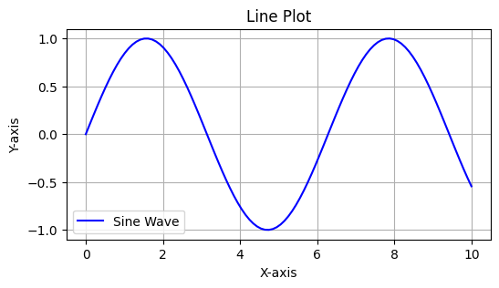

```python
x = np.linspace(0, 10, 100)
y = np.sin(x)

# Line plot

plt.figure(figsize=(6, 3))
plt.plot(x, y, label='Sine Wave', color='blue')
plt.title('Line Plot')
plt.xlabel('X-axis')
plt.ylabel('Y-axis')
plt.legend()
plt.grid(True)

plt.savefig("sine.png")
plt.show()
```

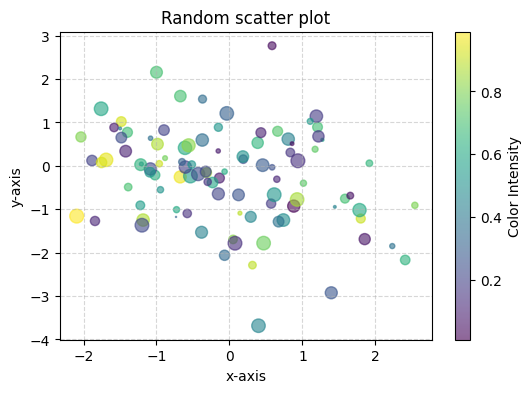

```python
x = np.random.randn(100)
y = np.random.randn(100)
colors = np.random.rand(100) # Random colors
sizes = np.random.rand(100) * 100 # Random sizes

# Scatter plot
plt.figure(figsize=(6, 4))
scatter = plt.scatter(x, y, c=colors, s=sizes, alpha=0.6, cmap='viridis')

# Add styling and labels
plt.title('Random scatter plot')
plt.xlabel('x-axis')
plt.ylabel('y-axis')
plt.colorbar(scatter, label='Color Intensity')
plt.grid(True, linestyle='--', alpha=0.5)

# Show the plot
plt.show()
```

```
(array([0, 1]), [Text(0, 0, 'Male'), Text(1, 0, 'Female')])
```

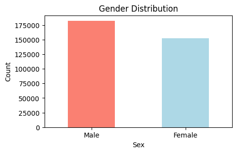

```python
plt.figure(figsize=(5, 3))

# bar plot

df['sex'].value_counts().plot(kind='bar', color=['salmon', 'lightblue'])
plt.title('Gender Distribution')
plt.xlabel('Sex')
plt.ylabel('Count')
plt.xticks(rotation=0)
```